# Predicting the presence of diabetes in patients through diagnostic measurements

## Phase 2: Predictive Modeling

### Group Name: Group 67

### Name and Student ID: Ting Li s3912985

- Introduction
  - Phase 1 Summary
  - Report Overview
  - Overview of Methodology
- Predictive Modeling
  - Feature Selection (FS)
  - Model Fitting & Tuning
  - Model Comparison
- Critique & Limitations
- Summary & Conclusions
  - Project Summary
  - Summary of Findings
  - Conclusions

## Introduction

### Phase 1 Summary

The project aims to predict diabetes in female patients of Pima Indian Heritage within 5 years of the initial examination, using 8 diagnostic measurements (UCI Machine Learning, 2017). Phase 1 of the project started with data preprocessing where unusual values and missing values were found in variable `Glucose`, `Blood_Pressure`, `Skin_Thickness`, `Insulin`, and `BMI`, so median imputation was performed for those variables. Then, data visualisation was were generated for Phase 1. Upon exploring Phase 1 visualisation, we found moderate correlation between `BMI` and `Skin_Thickness` and `Pregnancies` and `Age`. `Glucose` and `BMI` are found to be moderately correlated with the outcome of diabetes prediction in the dataset. We observed skewness in some variables and found that patients who are diagnosed with diabetes within 5 years (Outcome = 1), tend to have higher values in descriptive variables than those who were not diabetic in 5 years, especially for their value of Glucose. Phase 1 report Table 1 found class imbalance in the target feature, where 268 patients were diagnosed with diabetes and 500 patients were not diagnosed with diabetes within 5 years of the examination.

At the end of Phase 1, we planned to perform scaling in Phase 2 to normalise data so it suits machine learning (ML) algorithms that we'll use for Phase 2. The diabetes dataset used for Phase 2 has been preprocessed in Phase 1 and saved with `diabetes.to_csv("diabetesP1.csv", index=False)`.

### Report Overview

Following data preprocessing and visualisation in Phase 1, Phase 2 of the project aims to perform predictive modeling to predict whether a patient will have diabetes in 5 years, based on diagnostic measurements taken in the initial examination. Phase 2 will begin with an overview of the predictive modelling methodology, then moving on to: (1) perform data scaling, (2) select the best descriptive features with visualisation, (3) hyper-parameter fine-tuning and performance analysis of each ML algorithm with visualisation, and (4) compare performance of ML algorithms. In the end, we will discuss critique and limitations of the approach, and provide summary and conclusions of findings and the project.

### Overview of Methodology

Phase 2 will use the following classifiers to predict the target feature:

- K-Nearest Neighbors (KNN)
- Decision Trees (DT)
- Random Forest (RF)

`KNN` is similarity-based learning. It uses the distance between data points to determine the nearest neighbors, and classifies new data points based on their similarities to those neighbors. `DT` is information-based learning. It uses the most informative to split the dataset with respect to the target feature value. `RF` is an ensemble method that multiple DTs are combined with bagging and subspace sampling and makes predictions by returning the majority vote.

In the `Predictive Modeling` section, we will first perform scaling on descriptive features to transform data to a range between 0 and 1. For `DT` and `RF`, scaling ensures that features with larger scales such as `Insulin` are not overpowering during splitting, making sure all descriptive features have equal contribution. For `KNN`, scaling ensures that distance calculation is not biased due to features having different scales.

We will then perform feature selection using Random Forest Importance (RFI) and spFSR. `RFI` is filter-based. It calculates the average decrease in node impurities (measured by Gini index)from splitting on a particular feature over all decision trees in the ensemble. `spFSR` uses binary stochastic approximation to select the best features that's suitable for each classifier used. For feature selection in in Phase 2 we use spFSR as a filter so it is not bound by the specific classifier.

Model fitting and fine-tuning is the next step in predictive modeling, where we tune the hyperparameters of `KNN`, `DT` and `RF` to find the optimal hyperparameters for each ML algorithms to be use on the diabetes dataset, using cross-validation.

Lastly, we compare the performance of `KNN`, `DT`, and `RF` based on different metrics such as cross-validation, visualisation of ROC curve, accuracy, confusion matrix, and classification report. A combination of paired t-test and visual inspection will be used to determine the best model to be used to predict the presence of diabetes in patients.

## Predictive Modeling

This section includes steps for predictive modeling as demonstrated in Math2319 course materials, the course website (www.featureranking.com) and `sklearn` user guide (Scikit Learn, 2023).

```python
import warnings
warnings.filterwarnings("ignore")
```

```python
# Import modules
import numpy as np
import pandas as pd
from sklearn import preprocessing
from scipy import stats
from sklearn.model_selection import train_test_split
from sklearn.neighbors import KNeighborsClassifier
from sklearn.tree import DecisionTreeClassifier
from sklearn.ensemble import RandomForestClassifier
from sklearn import feature_selection as fs
from spFSR import SpFSR
from sklearn.model_selection import cross_val_score, RepeatedStratifiedKFold, GridSearchCV
from sklearn import metrics

#for plotting and display
import matplotlib.pyplot as plt
%matplotlib inline
%config InlineBackend.figure_format = 'retina'
plt.style.use("ggplot")

pd.set_option('display.max_columns', None)
```

```python
#import diabetesP1.csv
#this is clean data saved after preprocessing steps in Phase 1)
diabetes = pd.read_csv("diabetesP1.csv")
diabetes.sample(10, random_state=999)
```

|  | Pregnancies | Glucose | Blood_Pressure | Skin_Thickness | Insulin | BMI | Diabetes_Pedigree_Function | Age | Outcome |
| --- | --- | --- | --- | --- | --- | --- | --- | --- | --- |
| 441 | 2 | 83 | 66 | 23 | 50.0 | 32.2 | 0.497 | 22 | 0 |
| 57 | 0 | 100 | 88 | 60 | 110.0 | 46.8 | 0.962 | 31 | 0 |
| 68 | 1 | 95 | 66 | 13 | 38.0 | 19.6 | 0.334 | 25 | 0 |
| 95 | 6 | 144 | 72 | 27 | 228.0 | 33.9 | 0.255 | 40 | 0 |
| 411 | 1 | 112 | 72 | 30 | 176.0 | 34.4 | 0.528 | 25 | 0 |
| 192 | 7 | 159 | 66 | 23 | 30.5 | 30.4 | 0.383 | 36 | 1 |
| 352 | 3 | 61 | 82 | 28 | 30.5 | 34.4 | 0.243 | 46 | 0 |
| 400 | 4 | 95 | 64 | 23 | 30.5 | 32.0 | 0.161 | 31 | 1 |
| 677 | 0 | 93 | 60 | 23 | 30.5 | 35.3 | 0.263 | 25 | 0 |
| 376 | 0 | 98 | 82 | 15 | 84.0 | 25.2 | 0.299 | 22 | 0 |

```python
# partition into descriptive features and target feature
Data = diabetes.drop(columns='Outcome').values
target = diabetes['Outcome'].values
```

We imported the clean diabetes dataset after preprocessing steps were performed in Phase 1, and partitioned them into descriptive features and the target feature. Since `Outcome` was already encoded to 0 and 1, we do not need to encode the target feature.

As outlined in our methodology, we must perform scaling before feature selection and model fitting for selected ML algorithms to perform well.

```python
#scaling descriptive features
Data = preprocessing.MinMaxScaler().fit_transform(Data)
```

### Feature Selection (FS)

Since the diabetes dataset only has 768 observations, we use cross-validation instead of the hold-out method for the small dataset, also to avoid the lucky split. As outlined in our methodology, we use RFI and spFSR to select the best features, and compare the results of cross-validation between the full model, and models with features selected by RFI and spFSR methods, and we will do so for each ML algorithm (KNN, DT and RF).

The cross-validation method used is a stratified 5-fold cross-validation with 3 repetitions. As class imbalance exists in the diabetes dataset, we use stratification to make sure the proportion of each `Outcome` (diagnosed or not diagnosed with diabetes) in both train and test sets remain the same as full dataset in each cross-validation repetition.

For scoring metric, we set it to roc_auc because it is insensitive to class imbalance. Also, we want to optimize the model's performance on identifying positive cases to diagnose the presence of diabetes in patients.

```python
cv_method = RepeatedStratifiedKFold(n_splits=5,
                                     n_repeats=3,
                                     random_state=999)
scoring_metric = 'roc_auc'
```

#### Full Model

First, we set benchmark with full models where all descriptive features are included.

- KNN:0.79
- DT:0.679
- RF:0.826

```python
#KNN full model
cv_results_full_knn = cross_val_score(estimator=KNeighborsClassifier(),
                             X=Data,
                             y=target,
                             cv=cv_method,
                             scoring=scoring_metric)
cv_results_full_knn.mean().round(3)
```

```
0.79
```

```python
#DT full model
cv_results_full_dt = cross_val_score(estimator=DecisionTreeClassifier(),
                             X=Data,
                             y=target,
                             cv=cv_method,
                             scoring=scoring_metric)
cv_results_full_dt.mean().round(3)
```

```
0.679
```

```python
#RF full model
cv_results_full_rf = cross_val_score(estimator=RandomForestClassifier(),
                             X=Data,
                             y=target,
                             cv=cv_method,
                             scoring=scoring_metric)
cv_results_full_rf.mean().round(3)
```

```
0.826
```

We set `num_features = 5` to tell RFI and spFSR to select 5 best features.

```python
num_features = 5
```

#### Random Forest Importance (RFI)

First, we set `n_estimators=100` to perform feature selection using 100 trees. By fitting the RFI model to the diabetes dataset we get indices of the 5 best features based on sorted importance.

```python
model_rfi = RandomForestClassifier(n_estimators=100)
model_rfi.fit(Data, target)
fs_indices_rfi = np.argsort(model_rfi.feature_importances_)[::-1][0:num_features]
```

We obtain names of the 5 selected features: `Glucose`, `BMI`, `Age`, `Diabetes_Pedigree_Function`,`Pregnancies` based on RFI feature selection.

```python
best_features_rfi = diabetes.columns[fs_indices_rfi].values
best_features_rfi
```

```
array(['Glucose', 'BMI', 'Age', 'Diabetes_Pedigree_Function',
       'Pregnancies'], dtype=object)
```

```python
feature_importances_rfi = model_rfi.feature_importances_[fs_indices_rfi]
feature_importances_rfi
```

```
array([0.27227109, 0.16454492, 0.14016973, 0.1222462 , 0.07929239])
```

Using names of the 5 selected features and their importance obtained above, we plot Random Forest feature importances in Figure 1 below. We can see that `Glucose` is the most important feature based on RFI, and is leading with a large gap among the 5 features. This confirms our assumption in Phase 1 that `Glucose` is one of the most important descriptive feature in the diabetes dataset.

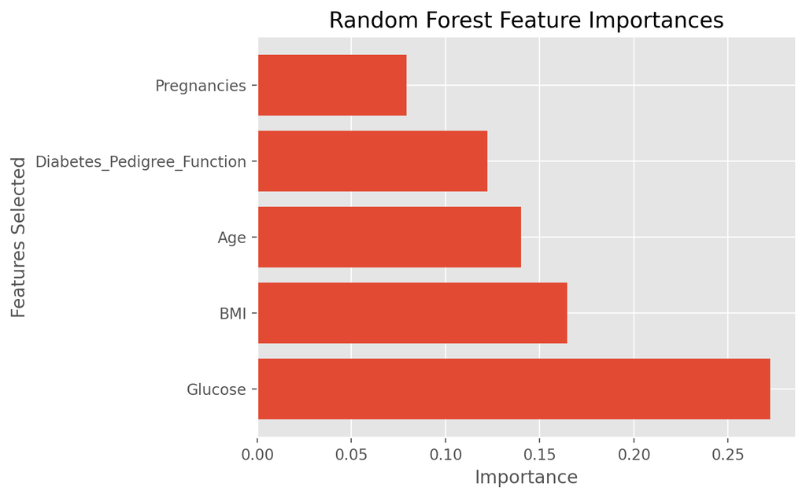

```python
plt.barh(best_features_rfi, feature_importances_rfi)
plt.title('Figure 1: Random Forest Feature Importances')
plt.xlabel("Importance")
plt.ylabel("Features Selected")
plt.show()
```

We obtain cross-validation results for KNN, DT and RF, using 5 features selected by the RFI method.

- KNN:0.786
- DT:0.679
- RF:0.823

```python
cv_results_rfi_knn = cross_val_score(estimator=KNeighborsClassifier(),
                             X=Data[:, fs_indices_rfi],
                             y=target,
                             cv=cv_method,
                             scoring=scoring_metric)
cv_results_rfi_knn.mean().round(3)
```

```
0.786
```

```python
cv_results_rfi_dt = cross_val_score(estimator=DecisionTreeClassifier(),
                             X=Data[:, fs_indices_rfi],
                             y=target,
                             cv=cv_method,
                             scoring=scoring_metric)
cv_results_rfi_dt.mean().round(3)
```

```
0.679
```

```python
cv_results_rfi_rf = cross_val_score(estimator=RandomForestClassifier(),
                             X=Data[:, fs_indices_rfi],
                             y=target,
                             cv=cv_method,
                             scoring=scoring_metric)
cv_results_rfi_rf.mean().round(3)
```

```
0.823
```

#### spFSR

Next, we define an spFSR object with `roc_auc` as the scoring metric for the same reason as stated above.

```python
#set spFSR
sp_engine = SpFSR(x=Data, y=target, pred_type='c', wrapper=None, scoring='roc_auc')
np.random.seed(999)
sp_output = sp_engine.run(num_features=num_features).results
```

```
SpFSR-INFO: Wrapper: RandomForestClassifier(class_weight='balanced_subsample', n_estimators=5,
                       random_state=1)
SpFSR-INFO: Hot start: True
SpFSR-INFO: Hot start range: 0.2
SpFSR-INFO: Feature weighting: False
SpFSR-INFO: Scoring metric: roc_auc
SpFSR-INFO: Number of jobs: 1
SpFSR-INFO: Number of observations in the dataset: 768
SpFSR-INFO: Number of observations used: 768
SpFSR-INFO: Number of features available: 8
SpFSR-INFO: Number of features to select: 5
SpFSR-INFO: iter_no: 0, num_ft: 5, value: 0.771, st_dev: 0.034, best: 0.771 @ iter_no 0
SpFSR-INFO: ===> iter_no: 5, same feature stall limit reached, initializing search...
SpFSR-INFO: iter_no: 10, num_ft: 5, value: 0.712, st_dev: 0.051, best: 0.784 @ iter_no 4
SpFSR-INFO: ===> iter_no: 16, same feature stall limit reached, initializing search...
SpFSR-INFO: iter_no: 20, num_ft: 5, value: 0.768, st_dev: 0.036, best: 0.784 @ iter_no 4
SpFSR-INFO: ===> iter_no: 22, same feature stall limit reached, initializing search...
SpFSR-INFO: iter_no: 30, num_ft: 5, value: 0.744, st_dev: 0.037, best: 0.784 @ iter_no 4
SpFSR-INFO: ===> iter_no: 31, same feature stall limit reached, initializing search...
SpFSR-INFO: iter_no: 40, num_ft: 5, value: 0.762, st_dev: 0.039, best: 0.784 @ iter_no 4
SpFSR-INFO: ===> iter_no: 42, same feature stall limit reached, initializing search...
SpFSR-INFO: iter_no: 50, num_ft: 5, value: 0.753, st_dev: 0.028, best: 0.784 @ iter_no 4
SpFSR-INFO: ===> iter_no: 59, same feature stall limit reached, initializing search...
SpFSR-INFO: iter_no: 60, num_ft: 5, value: 0.78, st_dev: 0.043, best: 0.784 @ iter_no 4
SpFSR-INFO: ===> iter_no: 64, same feature stall limit reached, initializing search...
SpFSR-INFO: iter_no: 70, num_ft: 5, value: 0.768, st_dev: 0.042, best: 0.784 @ iter_no 4
SpFSR-INFO: ===> iter_no: 72, same feature stall limit reached, initializing search...
SpFSR-INFO: ===> iter_no: 78, same feature stall limit reached, initializing search...
SpFSR-INFO: iter_no: 80, num_ft: 5, value: 0.734, st_dev: 0.028, best: 0.784 @ iter_no 4
SpFSR-INFO: ===> iter_no: 84, same feature stall limit reached, initializing search...
SpFSR-INFO: iter_no: 90, num_ft: 5, value: 0.738, st_dev: 0.038, best: 0.784 @ iter_no 4
SpFSR-INFO: ===> iter_no: 93, same feature stall limit reached, initializing search...
SpFSR-INFO: iter_no: 100, num_ft: 5, value: 0.765, st_dev: 0.031, best: 0.784 @ iter_no 4
SpFSR-INFO: SpFSR completed in 1.45 minutes.
SpFSR-INFO: Best value = 0.784 with 5 features and 100 total iterations.
```

By running the sp engine we get indices of the 5 best features below.

```python
fs_indices_spfsr = sp_output.get('selected_features')
fs_indices_spfsr
```

```
[1, 5, 0, 2, 7]
```

Names of the 5 selected features: `Glucose`, `BMI`, `Pregnancies`, `Blood_Pressure`, and `Age` based on spFSR feature selection.

```python
best_features_spfsr = diabetes.columns[fs_indices_spfsr]
best_features_spfsr
```

```
Index(['Glucose', 'BMI', 'Pregnancies', 'Blood_Pressure', 'Age'], dtype='object')
```

```python
feature_importances_spfsr = sp_output.get('selected_ft_importance')
feature_importances_spfsr
```

```
array([ 0.11189716,  0.01997353,  0.00448996, -0.01707774, -0.0211342 ])
```

Using names of the 5 selected features and their importance obtained above, we plot spFSR feature importances in Figure 2 below. Figure 2 confirms that `Glucose` is still the most important feature based on spFSR, and is leading with a large gap among the 5 features. RFI and spFSR selected r features in common: `Glucose`, `BMI`, `Pregnancies`, and `Age`. However, spFSR thinks `Blood_Pressure` is more important than `Diabetes_Pedigree_Function` (selected by RFI).

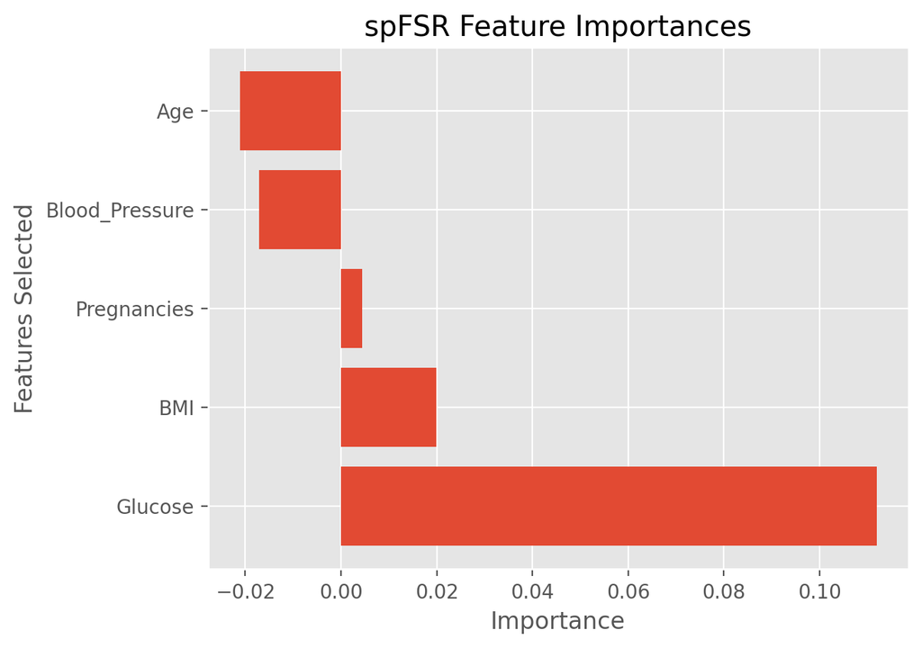

```python
plt.barh(best_features_spfsr, feature_importances_spfsr)
plt.title('Figure 2: spFSR Feature Importances')
plt.xlabel("Importance")
plt.ylabel("Features Selected")
plt.show()
```

We obtain cross-validation results for KNN, DT and RF, using 5 features selected by the spFSR method.

- KNN:0.794
- DT:0.678
- RF:0.815

```python
cv_results_spfsr_knn = cross_val_score(estimator=KNeighborsClassifier(),
                             X=Data[:, fs_indices_spfsr],
                             y=target,
                             cv=cv_method,
                             scoring=scoring_metric)
cv_results_spfsr_knn.mean().round(3)
```

```
0.794
```

```python
cv_results_spfsr_dt = cross_val_score(estimator=DecisionTreeClassifier(),
                             X=Data[:, fs_indices_spfsr],
                             y=target,
                             cv=cv_method,
                             scoring=scoring_metric)
cv_results_spfsr_dt.mean().round(3)
```

```
0.678
```

```python
cv_results_spfsr_rf = cross_val_score(estimator=RandomForestClassifier(),
                             X=Data[:, fs_indices_spfsr],
                             y=target,
                             cv=cv_method,
                             scoring=scoring_metric)
cv_results_spfsr_rf.mean().round(3)
```

```
0.815
```

To recap, cv results from RFI method are:

- KNN:0.786
- DT:0.679
- RF:0.823

cv results from full models are:

- KNN:0.79
- DT:0.679
- RF:0.826

Compared with cv results from RFI and spFSR method, the full models for DT and RF seem to perform better than those with selected 5 features. But for KNN, cv result from spFSR method with 5 features is best with 0.794, compared to 0.786 with RFI with 5 features, and 0.79 with the full model.

To determine if the differences are statistically significant, we perform paired t-test below. If the p-value is smaller than 0.05, we conclude that the difference is statistically significant at 95% significance level.

```python
#RFI vs. spFSR
print(stats.ttest_rel(cv_results_rfi_knn, cv_results_spfsr_knn).pvalue.round(3))
print(stats.ttest_rel(cv_results_rfi_dt, cv_results_spfsr_dt).pvalue.round(3))
print(stats.ttest_rel(cv_results_rfi_rf, cv_results_spfsr_rf).pvalue.round(3))
```

```
0.279
0.92
0.071
```

##### RFI vs. spFSR

As all p-values are greater than 0.05, results above indicates that when selecting 5 features from the diabetes dataset differences in cross-validation results between the RFI method and spFSR method is not statistically significant.

```python
#Full vs. spFSR
print(stats.ttest_rel(cv_results_spfsr_knn, cv_results_full_knn).pvalue.round(3))
print(stats.ttest_rel(cv_results_spfsr_dt, cv_results_full_dt).pvalue.round(3))
print(stats.ttest_rel(cv_results_spfsr_rf, cv_results_full_rf).pvalue.round(3))
```

```
0.558
0.946
0.003
```

##### Full vs. spFSR

Result above shows that differences in performance of KNN and DT model with 5 features selected with spFSR method, and KNN and DT full models are not statistically significant. (p-values greater than 0.05). However, for the RF model, the full model performs better than the RF model with 5 features selected using spFSR method. The difference is statistically significant as p<0.05.

```python
#RFI vs. Full
print(stats.ttest_rel(cv_results_rfi_knn, cv_results_full_knn).pvalue.round(3))
print(stats.ttest_rel(cv_results_rfi_dt, cv_results_full_dt).pvalue.round(3))
print(stats.ttest_rel(cv_results_rfi_rf, cv_results_full_rf).pvalue.round(3))
```

```
0.519
0.921
0.472
```

##### RFI vs. Full

Since all p-values are greater than 0.05, result above for `RFI vs. Full` indicates that when selecting 5 features from the diabetes dataset, differences in cross-validation results between the RFI method and the full model with all features is not statistically significant.

Based on results from all paired t-test, we will proceed using full features from the diabetes dataset.

### Model Fitting & Tuning

We split data into into 70:30 train and test sets to prevent over-fitting. We will use the train set for model fitting and fine-tuning of hyperparameters, and the test sets for model comparison.

As specified in Phase 1 summary, due to the uneven proportion of classes in the target feature, we set the stratify = target to mitigate the impact of class imbalance.

We continue to use cv method and scoring metric set in the Feature Selection stage.

```python
#split data into train and test sets
D_train, D_test, t_train, t_test = \
    train_test_split(Data, target, test_size = 0.3,
                     stratify=target, shuffle=True, random_state=999)
```

#### KNN

First we set parameters to be fine-tuned `n_neighbors` and `p` (1= Manhattan, 2 = Euclidean).

```python
params_knn = {'n_neighbors': [1, 3, 5, 7, 9, 11, 13, 15],
              'p': [1, 2]}
```

Grid search is performed to find the best set of parameters for the KNN model, the train set is used for model fitting.

```python
gs_knn = GridSearchCV(estimator=KNeighborsClassifier(),
                      param_grid=params_knn,
                      cv=cv_method,
                      n_jobs=-2,
                      verbose=1,
                      scoring=scoring_metric,
                      return_train_score=True)

gs_knn.fit(D_train, t_train);
```

The optimal number of neighbours are found to be 15 and Manhattan distance is the optimal distance to use (p=1). We continue to find test scores, with the best test score being 0.8137.

```python
gs_knn.best_params_
```

```
{'n_neighbors': 15, 'p': 1}
```

```python
gs_knn.best_score_
```

```
0.8137272234640655
```

```python
gs_knn.cv_results_['mean_test_score']
```

```
array([0.65002506, 0.65018492, 0.7511688 , 0.73880749, 0.7851077 ,
       0.77401477, 0.79430434, 0.7952154 , 0.80168021, 0.80169037,
       0.80548906, 0.81006435, 0.80983235, 0.80867439, 0.81372722,
       0.80666802])
```

```python
tuning_results_knn = pd.DataFrame(gs_knn.cv_results_['params'])
tuning_results_knn['test_score'] = gs_knn.cv_results_['mean_test_score']
sorted_tuning_results_knn = tuning_results_knn.sort_values(by='test_score', ascending=False)
sorted_tuning_results_knn.head(10)
```

|  | n_neighbors | p | test_score |
| --- | --- | --- | --- |
| 14 | 15 | 1 | 0.813727 |
| 11 | 11 | 2 | 0.810064 |
| 12 | 13 | 1 | 0.809832 |
| 13 | 13 | 2 | 0.808674 |
| 15 | 15 | 2 | 0.806668 |
| 10 | 11 | 1 | 0.805489 |
| 9 | 9 | 2 | 0.801690 |
| 8 | 9 | 1 | 0.801680 |
| 7 | 7 | 2 | 0.795215 |
| 6 | 7 | 1 | 0.794304 |

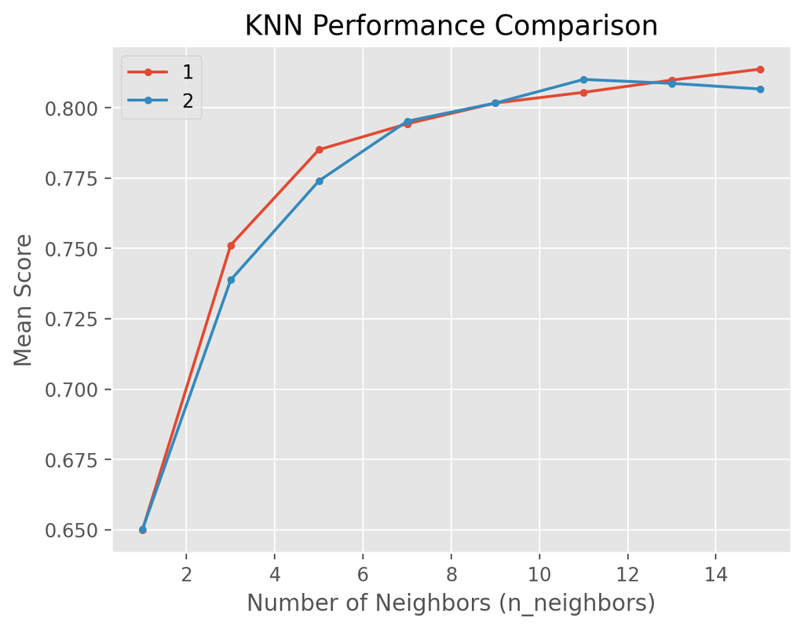

```python
for i in [1,2]:
    temp = tuning_results_knn[tuning_results_knn['p'] == i]
    plt.plot(temp['n_neighbors'], temp['test_score'], marker = '.', label = i)

plt.legend()
plt.xlabel('Number of Neighbors (n_neighbors)')
plt.ylabel("Mean Score")
plt.title("Figure 3: KNN Performance Comparison")
plt.show()
```

#### DT

We set parameters to be fine-tuned `criterion`, `max_depth` and `min_samples_split`. `criterion` determines whether the Gini impurity index or information gain (entropy) is used to measure quality of split. `max_depth` controls maximum depth of the tree. `min_samples_split` sets the minimum number of samples required to split at a node.

A DF classifier is set using random_state=999 and used for grid search.

```python
df_classifier = DecisionTreeClassifier(random_state=999)

params_dt = {'criterion': ['gini', 'entropy'],
             'max_depth': [1, 2, 3, 4, 5, 6, 7, 8],
             'min_samples_split': [2, 3]}

gs_dt = GridSearchCV(estimator=df_classifier,
                     param_grid=params_dt,
                     cv=cv_method,
                     n_jobs=-2,
                     verbose=1,
                     scoring=scoring_metric)

gs_dt.fit(D_train, t_train);
```

The optimal criterion is found to be entropy with a maximum depth of 4 and minimum number of samples required to split at a node set to 2.

We found best test score to be 0.7768.

```python
gs_dt.best_params_
```

```
{'criterion': 'entropy', 'max_depth': 4, 'min_samples_split': 2}
```

```python
gs_dt.best_score_
```

```
0.7768353315721737
```

We observe that the performance peaks at max_depth=4, and the entropy criterion almost always outperforms the gini criterion.

```python
tuning_results_dt = pd.DataFrame(gs_dt.cv_results_['params'])

tuning_results_dt['test_score'] = gs_dt.cv_results_['mean_test_score']
sorted_tuning_results_dt = tuning_results_dt.sort_values(by='test_score', ascending=False)
sorted_tuning_results_dt.head(10)
```

|  | criterion | max_depth | min_samples_split | test_score |
| --- | --- | --- | --- | --- |
| 23 | entropy | 4 | 3 | 0.776835 |
| 22 | entropy | 4 | 2 | 0.776835 |
| 6 | gini | 4 | 2 | 0.764694 |
| 7 | gini | 4 | 3 | 0.764694 |
| 21 | entropy | 3 | 3 | 0.762576 |
| 20 | entropy | 3 | 2 | 0.762576 |
| 4 | gini | 3 | 2 | 0.759818 |
| 5 | gini | 3 | 3 | 0.759818 |
| 24 | entropy | 5 | 2 | 0.753728 |
| 25 | entropy | 5 | 3 | 0.753263 |

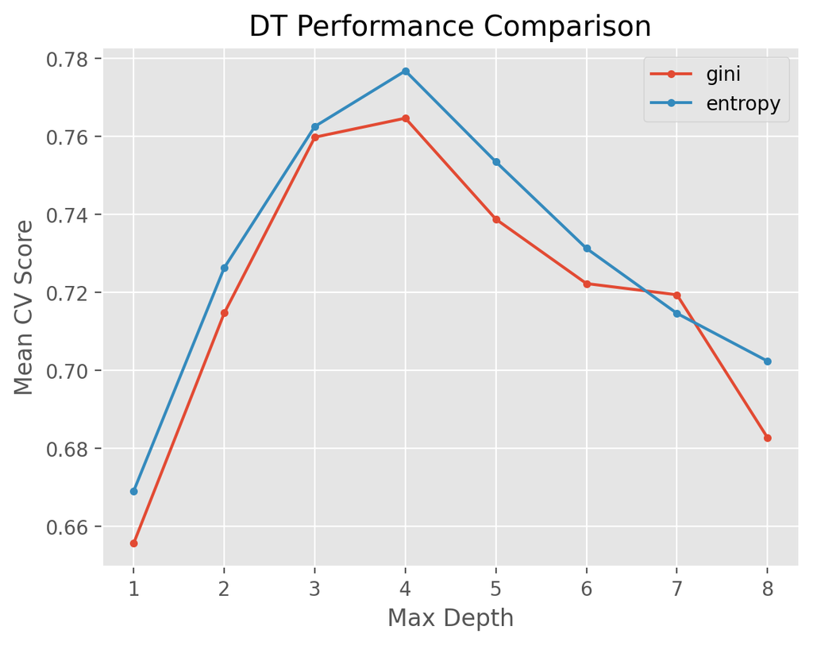

```python
for i in ['gini', 'entropy']:
    temp = tuning_results_dt[tuning_results_dt['criterion'] == i]
    temp_average = temp.groupby('max_depth').agg({'test_score': 'mean'})
    plt.plot(temp_average, marker = '.', label = i)


plt.legend()
plt.xlabel('Max Depth')
plt.ylabel("Mean CV Score")
plt.title("Figure 4: DT Performance Comparison")
plt.show()
```

#### RF

First, we set parameters to be fine-tuned. `n_estimators` specifies number of decision trees in the forest. `criterion` determines whether the Gini impurity index or information gain (entropy) is used to measure quality of split. `max_depth` controls maximum depth of each tree in the forest. `min_samples_split` sets the minimum number of samples required to split at a node in each decision tree. `class_weight` is used to address class imbalance in the dataset.

A RF classifier is set using random_state=999 and used for grid search.

```python
rf_classifier = RandomForestClassifier(random_state=999)

params_rf = {'n_estimators': [10, 50, 100, 200, 400],
            'criterion': ['gini', 'entropy'],
            'max_depth': [None, 5, 10],
            'min_samples_split': [2, 5, 10],
            'class_weight': ['balanced', 'balanced_subsample']}

gs_rf = GridSearchCV(estimator=rf_classifier,
                    param_grid=params_rf,
                    cv=cv_method,
                    n_jobs=-2,
                    verbose=1,
                    scoring=scoring_metric)

gs_rf.fit(D_train, t_train);
```

After training, we found the optimal is to have 200 trees in the forest, use entropy, set no maximum depth of each tree in the random forest, set minimum 10 samples to split at a node in each decision tree, and to apply weights to different classes per-tree. The best score for RF is 0.8322.

```python
gs_rf.best_params_
```

```
{'class_weight': 'balanced_subsample',
 'criterion': 'entropy',
 'max_depth': None,
 'min_samples_split': 10,
 'n_estimators': 200}
```

```python
gs_rf.best_score_
```

```
0.8322407369775792
```

```python
tuning_results_rf = pd.DataFrame(gs_rf.cv_results_['params'])

tuning_results_rf['test_score'] = gs_rf.cv_results_['mean_test_score']
sorted_tuning_results_rf = tuning_results_rf.sort_values(by='test_score', ascending=False)
sorted_tuning_results_rf.head(10)
```

|  | class_weight | criterion | max_depth | min_samples_split | n_estimators | test_score |
| --- | --- | --- | --- | --- | --- | --- |
| 148 | balanced_subsample | entropy | NaN | 10 | 200 | 0.832241 |
| 88 | balanced | entropy | 10.0 | 10 | 200 | 0.831902 |
| 89 | balanced | entropy | 10.0 | 10 | 400 | 0.831795 |
| 43 | balanced | gini | 10.0 | 10 | 200 | 0.831711 |
| 59 | balanced | entropy | NaN | 10 | 400 | 0.831603 |
| 179 | balanced_subsample | entropy | 10.0 | 10 | 400 | 0.831441 |
| 163 | balanced_subsample | entropy | 5.0 | 10 | 200 | 0.831326 |
| 133 | balanced_subsample | gini | 10.0 | 10 | 200 | 0.831290 |
| 13 | balanced | gini | NaN | 10 | 200 | 0.831076 |
| 149 | balanced_subsample | entropy | NaN | 10 | 400 | 0.831024 |

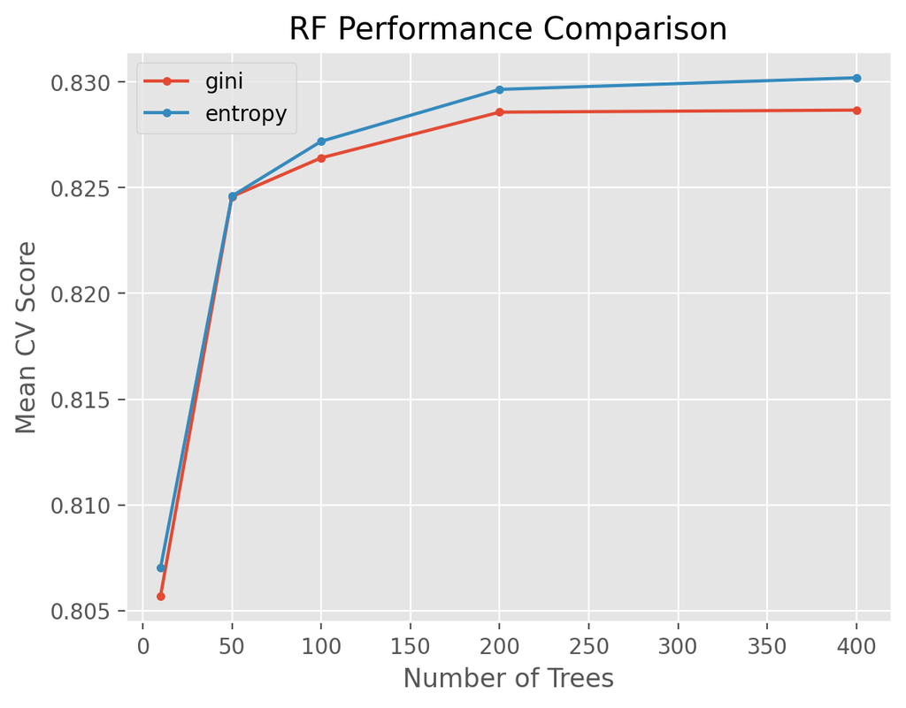

```python
for i in ['gini', 'entropy']:
    temp = tuning_results_rf[tuning_results_rf['criterion'] == i]
    temp_average = temp.groupby('n_estimators').agg({'test_score': 'mean'})
    plt.plot(temp_average, marker = '.', label = i)


plt.legend()
plt.xlabel('Number of Trees')
plt.ylabel("Mean CV Score")
plt.title("Figure 5: RF Performance Comparison")
plt.show()
```

### Model Comparison

After model fitting and fine-tuning, we found the best hyperparameter values for KNN, DT and RF. We now fit each classifier with `best_estimator_` to the test dataset to compare their performance.

```python
cv_results_best_knn = cross_val_score(estimator=gs_knn.best_estimator_,
                             X=D_test,
                             y=t_test,
                             cv=cv_method,
                             scoring=scoring_metric)
cv_results_best_knn.mean().round(3)
```

```
0.803
```

```python
cv_results_best_dt = cross_val_score(estimator=gs_dt.best_estimator_,
                             X=D_test,
                             y=t_test,
                             cv=cv_method,
                             scoring=scoring_metric)
cv_results_best_dt.mean().round(3)
```

```
0.696
```

```python
cv_results_best_rf = cross_val_score(estimator=gs_rf.best_estimator_,
                             X=D_test,
                             y=t_test,
                             cv=cv_method,
                             scoring=scoring_metric)
cv_results_best_rf.mean().round(3)
```

```
0.82
```

RF seems to perform better, followed closely by KNN. DT does not seem to perform well compared to RF and KNN. We now perform paired t-test to determine if the difference is statistically significant.

```python
print(f" KNN vs. DT p = {stats.ttest_rel(cv_results_best_knn, cv_results_best_dt).pvalue} \n")
print(f" KNN vs. RF p = {stats.ttest_rel(cv_results_best_knn, cv_results_best_rf).pvalue} \n")
print(f" DT vs. RF p = {stats.ttest_rel(cv_results_best_dt, cv_results_best_rf).pvalue} \n")
```

```
 KNN vs. DT p = 1.8998338398509054e-05

 KNN vs. RF p = 0.0654688097103468

 DT vs. RF p = 5.403173081932473e-07
```

Upon inspection of p-values from paired t-test:

- for `KNN vs. DT` and `DT vs. RF`, p<0.05
- for `KNN vs. RF`, p>0.05

Therefore, the difference among cross-validation results betwee DT and the other 2 algorithms is statistically significant after fine-tuning, but the difference between KNN and RF best models are not. This result indicates that both KNN and RF perform better than DT. Now let's compare performance further with other metrics to determine whether KNN or RF is the best model.

##### Accuracy

Comparison of accuracy below shows the performance of KNN > RF > DT.

```python
t_pred_knn = gs_knn.best_estimator_.predict(D_test)
metrics.accuracy_score(t_test, t_pred_knn)
```

```
0.7965367965367965
```

```python
t_pred_dt = gs_dt.best_estimator_.predict(D_test)
metrics.accuracy_score(t_test, t_pred_dt)
```

```
0.7532467532467533
```

```python
t_pred_rf = gs_rf.best_estimator_.predict(D_test)
metrics.accuracy_score(t_test, t_pred_rf)
```

```
0.7878787878787878
```

##### Confusion Matrix

Confusion Matrix of KNN, DT and RF indicates that RF has the most true positives, followed by KNN and then DT. However, KNN performs better at classifying true negatives than RF. KNN also has the lease false positives, which is confirmed in the classification report in the next section.

```python
metrics.confusion_matrix(t_test, t_pred_knn)
```

```
array([[133,  17],
       [ 30,  51]])
```

```python
metrics.confusion_matrix(t_test, t_pred_dt)
```

```
array([[132,  18],
       [ 39,  42]])
```

```python
metrics.confusion_matrix(t_test, t_pred_rf)
```

```
array([[122,  28],
       [ 21,  60]])
```

##### Classification Report

Classification report indicates that:

- For precision, KNN > DT > RF, therefore KNN has the best accuracy of the positive predictions
- For recall, RF > KNN > DT, RF has the best sensitivity or true positive rate
- For f1-score, RF > KNN > DT, f1-score is the harmonic mean of precision and recall and RF has the highest

```python
print(f"For KNN: ")
print(metrics.classification_report(t_test, t_pred_knn))
```

```
For KNN:
              precision    recall  f1-score   support

           0       0.82      0.89      0.85       150
           1       0.75      0.63      0.68        81

    accuracy                           0.80       231
   macro avg       0.78      0.76      0.77       231
weighted avg       0.79      0.80      0.79       231
```

```python
print(f"For DT: ")
print(metrics.classification_report(t_test, t_pred_dt))
```

```
For DT:
              precision    recall  f1-score   support

           0       0.77      0.88      0.82       150
           1       0.70      0.52      0.60        81

    accuracy                           0.75       231
   macro avg       0.74      0.70      0.71       231
weighted avg       0.75      0.75      0.74       231
```

```python
print(f"For RF: ")
print(metrics.classification_report(t_test, t_pred_rf))
```

```
For RF:
              precision    recall  f1-score   support

           0       0.85      0.81      0.83       150
           1       0.68      0.74      0.71        81

    accuracy                           0.79       231
   macro avg       0.77      0.78      0.77       231
weighted avg       0.79      0.79      0.79       231
```

```python
print(f" For KNN: {metrics.roc_auc_score(t_test, t_pred_knn)}\n")
print(f" For DT: {metrics.roc_auc_score(t_test, t_pred_dt)}\n")
print(f" For RF: {metrics.roc_auc_score(t_test, t_pred_rf)}\n")
```

```
 For KNN: 0.7581481481481482

 For DT: 0.6992592592592592

 For RF: 0.777037037037037
```

RF also seems to have the highest roc_auc_score among the 3 ML algorithms.

```python
t_prob_knn = gs_knn.predict_proba(D_test)
fpr_knn, tpr_knn, _ = metrics.roc_curve(t_test, t_prob_knn[:, 1])
df_knn = pd.DataFrame({'fpr': fpr_knn, 'tpr': tpr_knn})
```

```python
t_prob_dt = gs_dt.predict_proba(D_test)
fpr_dt, tpr_dt, _ = metrics.roc_curve(t_test, t_prob_dt[:, 1])
df_dt = pd.DataFrame({'fpr': fpr_dt, 'tpr': tpr_dt})
```

```python
t_prob_rf = gs_rf.predict_proba(D_test)
fpr_rf, tpr_rf, _ = metrics.roc_curve(t_test, t_prob_rf[:, 1])
df_rf = pd.DataFrame({'fpr': fpr_rf, 'tpr': tpr_rf})
```

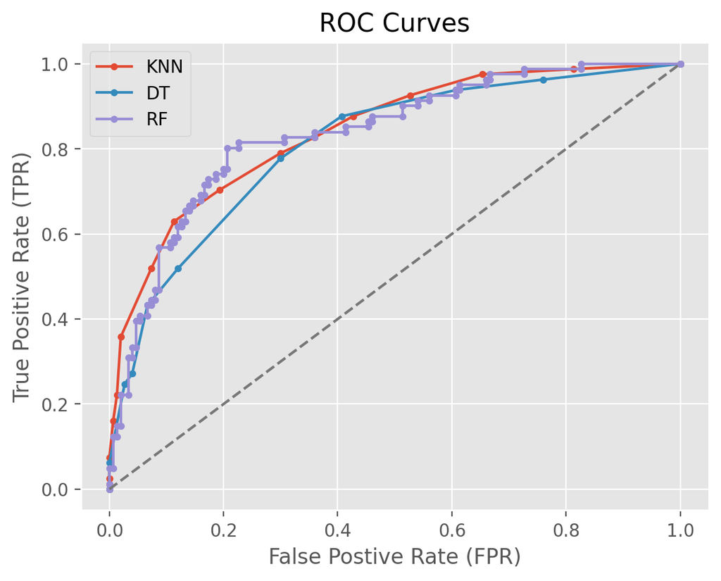

```python
plt.plot(df_knn['fpr'], df_knn['tpr'], label='KNN', marker='.')
plt.plot(df_dt['fpr'], df_dt['tpr'], label='DT', marker='.')
plt.plot(df_rf['fpr'], df_rf['tpr'], label='RF', marker='.')

plt.plot([0, 1], [0, 1], '--')
plt.xlabel("False Postive Rate (FPR)")
plt.ylabel("True Positive Rate (TPR)")
plt.title('Figure 6: ROC Curves')
plt.legend()
plt.show()
```

Overall, based on all model evaluation metrics above, RF seems to be the best model for predicting the presence of diabetes in patients after 5 years of the initial examination. The most important reason is that it performs better at finding the true positives, which is crucial to this specific problem of diabetes diagnosis.

## Critique & Limitations

My approach to Phase 2 of the project has its strength and limitations.

##### Strengths

Phase 2 of this project acknowledged and dealt with imbalanced class in the diabetes dataset. I have tried to mitigate the effect of class imbalance on model performance in various ways, such as the use of roc_auc, and stratification. Various evaluation metrics were used to compare the performance of KNN, DT and RF models after hyperparameter fine-tuning. A combination of visual inspection and statistical test on evaluation metrics allows me to evaluate more comprehensively and mitigate bias of using one evaluation metric. Also, the model used were simple, therefore requiring less computational time to perform.

##### Limitations

A major limitation of this project is insufficient data. The diabetes dataset has only 768 observations and 8 descriptive variables. The small dataset limits the model's ability to generalize towards new data. One way to mitigate this limitation is to collect more data and using them the train the model. Data quality is also an issue with the diabetes dataset. Phase 1 of the project found missing values for 5 descriptive variables. Due to the small dataset size, we could not drop observations with missing value and had to impute with median values, which led to large outliers in those variables. Having a larger dataset could mitigate this issue. Also, better domain knowledge of diagnostic measurements might help with data preprocessing, as we might find a better value than median to impute the data with.

Another issue with the project is the lack of more complex and interpretable machine learning algorithms. All 3 models fitted for the project are simple models and might not be able to capture more complex patterns underlying in the data, and could lead to underfitting. We could try to fine-tune more hyperparameters to improve performance of existing models. Employing algorithms such as Neural Networks might also mitigate this issue, however it is limited by the performance of my laptop.

## Summary & Conclusions

### Project Summary

The project has 2 phases.

Phase 1 of the project covered data cleaning, data preprocessing, data visualisation and exploration. For initial data observation, we found unusual values and missing values in variable Glucose, Blood_Pressure, Skin_Thickness, Insulin, and BMI, and impute with median values. We then inspected further on all variables to make sure the dataset was clean and moved on to data visualisation and exploration. Class imbalance was found for the target feature with 268 patients diagnosed with diabetes and 500 patients not diagnosed with diabetes within 5 years of the examination. From visualisations, we found moderate correlations between variables such as BMI and Skin_Thickness, and observed differences in descriptive variable values between two classes of the Outcome variable. The difference is most evident in variable `Glucose`, which is later confirmed to be the most important feature in Phase 2.

In Phase 2, we performed predictive modeling using 3 machine learning algorithms, K Nearest Neighbors (KNN), Decision Tree (DT) and Random Forest (RF). After an overview of methodology, we imported clean data saved after Phase 1, and split the dataset into descriptive features and the target feature. We performed scaling on descriptive features to transform data to better suit the algorithms used.

For model fitting and fine-tuning, the dataset is split into train set and test set. The train set was use for this section and the test set is saved for model evaluation when comparing model performance after fine-tuning of hyperparameters. We fine-tuned the hyperparameters of `KNN`, `DT` and `RF` to find the optimal hyperparameters for each ML algorithms to be use on the diabetes dataset, using cross-validation.

Then, we compare the performance of `KNN`, `DT`, and `RF` with their optimal hyperparameters using various metrics such as cross-validation, ROC curve, accuracy, confusion matrix, and classification report. We used paired t-test and visual inspection of evaluation metrics, and the RF model was found to be the best model for this project overall.

### Summary of Findings

From the diabetes dataset, we found `Glucose`, `BMI`, `Pregnancies`, and `Age` of more importance among measurements of 8 risk factors for diabetes in an examination. Researchers and medical professionals should pay more attention to these measurements during health check-up or screenings to better detect the presence of diabetes.

### Conclusions

Prevalence of diabetes is higher for the population of Pima Indian Heritage compared to other ethnicities. The RF model found in this project could be used to assist detection of diabetes from their' health check-up data, or to be used to predict other diseases and conditions for early prevention and intervention to save lives and medicare costs.

We need sufficient data to train and test algorithms to better predict the presence of diabetes. Therefore, stakeholders and data scientists should work together to generate better models for detection, prevention and intervention of diabetes and other diseases.

## References

Akman, D. (n.d.). Case Study: Predicting Income Status. https://www.featureranking.com/tutorials/machine-learning-tutorials/case-study-predicting-income-status/

Akman, D. (2022). Phase1_Report_Sample.ipynb [Jupyter Notebook]. GitHub. https://github.com/akmand/stats_tutorials/blob/main/Phase1_Report_Sample.ipynb

Akman, D. (2022). Predicting Age in Census Data.ipynb [Jupyter Notebook]. GitHub. https://github.com/akmand/stats_tutorials/blob/main/regression_case_study_predicting_age_in_census_data.ipynb

Centers for Disease Control and Prevention. (n.d.). Search results for diabetes. https://search.cdc.gov/search/?query=diabetes&dpage=1

Georgiou, S. (2023). Topic1_slides.pdf [PDF file]. Canvas@RMIT University. https://rmit.instructure.com/courses/112586/files/29073439?wrap=1

Scikit Learn (2023). User Guide. https://scikit-learn.org/stable/user_guide.html

Smith, J. W., Everhart, J. E., Dickson, W. C., Knowler, W. C., & Johannes, R. S. (1988). Using the ADAP learning algorithm to forecast the onset of diabetes mellitus. In Proceedings of the Symposium on Computer Applications and Medical Care. IEEE Computer Society Press, 261-265. https://www.astro.uvic.ca/~karun/UVic_ACML/Smith1988.pdf

Taheri, S (2021, Oct 1) Module 5 Notes, Data Wrangling [Course website]. http://rare-phoenix-161610.appspot.com/secured/Module_05.html.

World Health Organization. (2021, November 4). Diabetes. https://www.who.int/news-room/fact-sheets/detail/diabetes